# IEBE — Group Assignment

Group Number: 25

11-10-2026

# Instructions

Use this file for your group solutions.

- For the **tentative group submission**, complete Questions 1 and 2.
- After the group reshuffle, compare the earlier solutions brought by the members of your new group and agree on a common approach.
- For the **final group submission**, complete Questions 1-5.
- Your final file should contain the explanations, R code, relevant numerical results, tables, and figures needed to support your answers.
- Do not only paste R output. Interpret the results and answer the economic and econometric questions being asked.
- Use only methods and concepts covered in the course up to the corresponding question.

# Creating a readable output

RStudio can combine your written answers, R code, tables, and figures into a single document. To do this, click **Knit** at the top of the editor.

**You are submitting this `.Rmd` file**, so your most important task is to make sure that:

1. your written answers are in this file;
2. your R code is in this file; and
3. the code runs from top to bottom without relying on objects that only exist in your R workspace.

A good habit is to restart R and run the file from the beginning before submitting it.

# Submission instructions

When submitting your tentative group assignment in week 3, rename the group-assignment file to `GroupAssignment[GroupNumber].Rmd`. For example, group 12 should submit `GroupAssignment12.Rmd`. Please also make sure that the **group number is written inside the R Markdown file**.

Use the same naming convention for the final group assignment in week 6. After the group reshuffle, your new group may have a different group number. Therefore, make sure that both the file name and the group number written inside the file correspond to your **new group**.

# Getting started

We start by loading the data set alongside packages that we need.

```r
library(readxl)
library(sandwich)
library(lmtest)
library(car)

CPS1985 <- read_excel("CPS1985.xlsx")

#squared experience, used in Question 5
CPS1985$experience_sq <- CPS1985$experience^2
```

# Question 1

## (a) (1 pt)

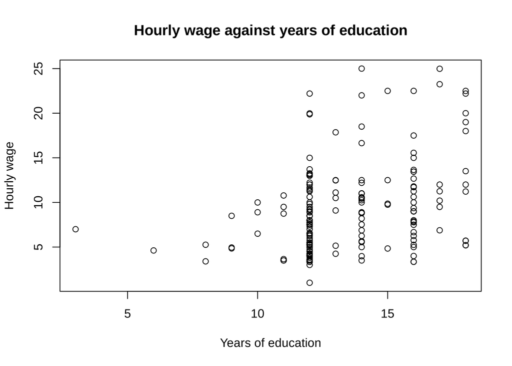

```r
plot(CPS1985$education, CPS1985$wage,
     xlab = "Years of education",
     ylab = "Hourly wage",
     main = "Hourly wage against years of education")
```

What changes with education is the spread of wages: above about 12 years of education there is substantial variation, as individuals with higher levels of education include both relatively high and relatively low earners. A straight line only describes the average wage at each education level, so it does not capture this increasing spread (we come back to this in 2(b)). Overall, the pattern seems approximately linear and upward-sloping.

## (b) (1 pt)

```r
model <- lm(wage ~ education, data = CPS1985)
summary(model)
```

```
##
## Call:
## lm(formula = wage ~ education, data = CPS1985)
##
## Residuals:
##     Min      1Q  Median      3Q     Max
## -7.7981 -3.4450 -0.6247  2.3019 15.3050
##
## Coefficients:
##             Estimate Std. Error t value Pr(>|t|)
## (Intercept)  -0.4766     1.9507  -0.244    0.807
## education     0.7265     0.1433   5.069 9.91e-07 ***
## ---
## Signif. codes:  0 '***' 0.001 '**' 0.01 '*' 0.05 '.' 0.1 ' ' 1
##
## Residual standard error: 4.682 on 179 degrees of freedom
## Multiple R-squared:  0.1255, Adjusted R-squared:  0.1207
## F-statistic:  25.7 on 1 and 179 DF,  p-value: 9.905e-07
```

```r
beta1 <- cov(CPS1985$education, CPS1985$wage) / var(CPS1985$education)

cat("Slope calculated from cov()/var():", beta1, "\n")
```

```
## Slope calculated from cov()/var(): 0.7265459
```

```r
cat("Slope estimated by lm():", coef(model)["education"], "\n")
```

```
## Slope estimated by lm(): 0.7265459
```

Regression Results:

Using `lm()`, the estimated simple linear regression model is
$$\widehat{wage}_i = -0.4766 +
0.7265\,education_i.$$

The estimated coefficient on education is 0.7265. This means that one additional year of education is associated with an increase of approximately $0.73 in hourly wage, on average.

The estimated intercept is -0.4766. This means that the predicted hourly wage for an individual with zero years of education is approximately -$0.48. However, this interpretation is not economically meaningful because a negative hourly wage is not realistic, and zero years of education is not a relevant value for the working population in this context. The intercept is mainly useful as part of the regression line.

Manual Verification of the Slope:

Using the sample covariance between education and wage and the sample variance of education, the manually calculated slope coefficient is 0.7265. This matches the slope estimate from lm() up to numerical rounding. Therefore, the manual calculation confirms the OLS estimate of the education coefficient.

## (c) (1 pt)

```r
fit_stats <- c(R_squared = summary(model)$r.squared, SER = summary(model)$sigma, SD_wage = sd(CPS1985$wage))
round(fit_stats, 4)
```

```
## R_squared       SER   SD_wage
##    0.1255    4.6820    4.9928
```

The regression produced an R^2 of 0.1255 and a standard error of the regression (SER) of 4.6820. The R^2 measures the fraction of the sample variance of wage that is explained by education. An R^2 of 0.1255 means that education explains 12.55% of the variation in hourly wages, while the remaining 87.4% is not explained by education and may reflect other factors, such as work experience or sex.

The SER estimates the spread of the distribution of the error term and measures the typical size of the OLS regression residuals, in the units of the dependent variable (dollars per hour). An SER of 4.6820 means that actual hourly wages typically deviate from the regression line by about $4.68. Because the SER almost corresponds to the sample standard deviation of the OLS residuals, it can be compared directly with the standard deviation of wage, which is about $4.99. An SER of $4.68 is only slightly smaller than the overall sample standard deviation of wage, indicating that education alone doesn’t predict individual wages very precisely.

A relatively low R^2 does not by itself imply that the estimated relationship between education and wages is uninteresting. R^2 is a measure of fit, it captures how much of the total variation in wage the regressors explain, but it says nothing about whether the estimated coefficient on education is economically meaningful or statistically significant. Wages are determined by many factors besides years of schooling, so it is expected that education alone leaves most of the variation in wages unexplained.

## (d) (1 pt)

```r
new_educ <- data.frame(education = c(12, 20, 30))

predicted_wages <- round(predict(model, newdata = new_educ), 2)
names(predicted_wages) <- c("12 years", "20 years", "30 years")

predicted_wages
```

```
## 12 years 20 years 30 years
##     8.24    14.05    21.32
```

```r
education_range <- c(Minimum = min(CPS1985$education), Maximum = max(CPS1985$education))
education_range
```

```
## Minimum Maximum
##       3      18
```

Using the fitted regression the predicted hourly wages are around $8.24 for 12 years of education, $14.05 for 20 years and $21.32 for 30 years. The observed range of education is 3 to 18 years. Since 12 years falls within this range, that prediction is an interpolation and is supported by the data. But 20 and 30 years lie outside the range, so those predictions are extrapolations. They assume the linear relationship continues beyond the observed data, which may not hold.

Not every prediction R calculates is automatically meaningful. R will compute a fitted value for any input you give it, but that doesn’t mean the prediction is realistic. For education = 30 especially, we are relying on the assumption that the same linear relationship between education and wage continues far beyond the data we actually observed. If we extrapolate too far this could produce wage predictions that are unrealistically high.

# Question 2

## (a) (1 pt)

```r
summary(CPS1985$wage)
```

```
##    Min. 1st Qu.  Median    Mean 3rd Qu.    Max.
##   1.000   5.260   8.500   9.253  11.670  25.000
```

```r
summary(CPS1985$education)
```

```
##    Min. 1st Qu.  Median    Mean 3rd Qu.    Max.
##    3.00   12.00   12.00   13.39   16.00   18.00
```

```r
# other wage determinants in the data that are related to education
aggregate(cbind(education, wage) ~ occupation, data = CPS1985, mean)
```

```
##   occupation education      wage
## 1 management  14.51724 11.294138
## 2     office  13.64865  7.517838
## 3      sales  12.72727  7.047273
## 4   services  12.42308  6.978846
## 5  technical  16.07143 13.065714
## 6     worker  11.70000  8.887600
```

```r
cor(CPS1985$education, CPS1985$experience)
```

```
## [1] -0.3737789
```

We consider the simple regression model:
$$wage_i = \beta_0 + \beta_1 education_i +
u_i$$

where wage_i is hourly wage, education_i is years of education, and u_i contains other factors that affect wages but are not included in the regression. The 3 least-squares assumptions discussed in the lecture are conditional exogeneity, i.i.d. observations, and the absence of large outliers.

1. Conditional exogeneity The first assumption is:
   $$E(u_i \mid education_i = x) = 0.$$

which means that factors contained in u_i should not be systematically related to education. This assumption is questionable in this application, because there could be many other factors that affect hourly wages, such as experience, occupation, gender, union membership, sector, and ethnicity. Some of these factors can also be related to education. For example, people with more education tend to work in different occupations, and occupation also affects wages. If these factors are omitted from the regression and are correlated with education, they end up in the error term $u_i$, and the conditional exogeneity assumption no longer holds.

The data give some evidence for this. Average education and average wage differ a lot by occupation: technical workers have on average 16.1 years of education and earn $13.07 per hour, while service workers have 12.4 years and earn $6.98. Experience is also clearly related to education (correlation of −0.37), because people who study longer start working later. Since occupation and experience are not in the simple regression, they are part of $u_i$, so $u_i$ likely correlates with education. Unobserved factors, like ability, can’t be checked with the data at all, so we still need economic reasoning to judge what might be missing.

2. i.i.d. observations

The second assumption is that
$$(X_i,Y_i),
\qquad i=1,\ldots,n,$$
are independently and identically distributed. This means that the observations come from the same population and are independently sampled. According to the lecture, this holds when the data are collected by simple random sampling. This assumption seems reasonable here, because the assignment says the 181 observations are a random subsample of the CPS1985 dataset, supporting the assumption that the observations are independently and identically distributed. However, this cannot be confirmed solely from the observed values, and we rely on the description of how the data were collected.

3. Large outliers in X and/or Y are rare

The third assumption is that large outliers in the explanatory variable or dependent variable are rare. Here, this means that there should be no extremely unusual values that could strongly affect the estimated coefficients. The observed data provide some evidence for assessing this assumption. Education ranges from 3 to 18 years, with a median of 12 and a mean of 13.39. Hourly wage ranges from $1 to $25, with a median of 8.50 and a mean of 9.253. The maximum of 18 years of education is relatively high but still realistic. Similarly, the maximum wage of $25 is high compared with the median, but it is still a realistic wage and not a clear outlier. Therefore, these values do not appear to be errors or extreme outliers, so this assumption seems reasonable.

Overall, the i.i.d. assumption and the assumption that large outliers are rare seem plausible here. Conditional exogeneity is more questionable because there are some other factors that affect wages and can also be related to education.

## (b) (1 pt)

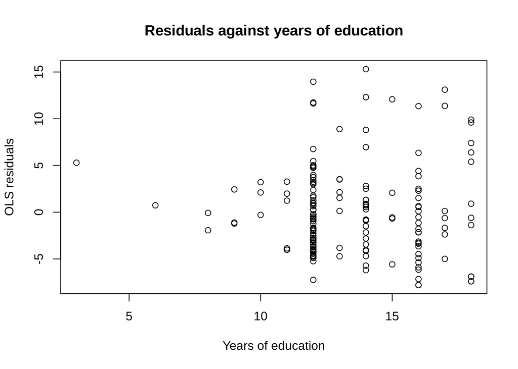

```r
residuals_model <- residuals(model)

plot(CPS1985$education, residuals_model,
     xlab = "Years of education",
     ylab = "OLS residuals",
     main = "Residuals against years of education")
```

The plot of residuals against years of education shows that the spread of the residuals changes with education. At low levels of education, below 12 years, the residuals stay close to zero, ranging from about −4 to 5. From 12 years onward, they are much more spread out, ranging from roughly −7 to 15, with both very large positive and large negative residuals at the same education levels.

Since the spread of the residuals increases with education instead of staying constant, the variance of the errors given education is not constant. The errors are heteroskedastic, not homoskedastic. If they were instead homoskedastic, we would expect to see that the residuals stay within a band of roughly the same width around zero for the entire range of education.

Heteroskedasticity does not mean that OLS can no longer be used to estimate the regression coefficients, and it does not necessarily make $\hat{\beta}_1$ biased. As long as the zero conditional mean assumption,
$$E(u_i
\mid X_i)=0,$$
still holds, the OLS estimator remains unbiased. However, heteroskedasticity means that the conditional variance of the error term,
$$\operatorname{Var}(u_i \mid
X_i),$$
is not constant across observations. Since the usual OLS standard-error formula assumes constant error variance, it is no longer appropriate when heteroskedasticity is present. As a result, the standard errors can be incorrect, which can make the corresponding t-statistics, p-values, and confidence intervals unreliable.

Therefore, heteroskedasticity-robust standard errors should be used. These do not change the estimated OLS coefficients. Instead, they adjust the estimated standard errors to account for the fact that the variance of the error term is not constant across observations. As a result, the corresponding t-statistics, p-values, and confidence intervals are more reliable when heteroskedasticity is present.

## (c) (1 pt)

```r
beta1 <- unname(coef(model)["education"])
se_beta1 <- sqrt(vcovHC(model, type = "HC1")["education", "education"])
df <- model$df.residual
t_critical <- qt(0.975, df)
lower <- beta1 - t_critical * se_beta1
upper <- beta1 + t_critical * se_beta1
c(lower, upper)
```

```
## [1] 0.4224031 1.0306888
```

```r
# robust (HC1) t-test
coeftest(model, vcov = vcovHC(model, type = "HC1"))
```

```
##
## t test of coefficients:
##
##             Estimate Std. Error t value  Pr(>|t|)
## (Intercept) -0.47661    1.97445 -0.2414    0.8095
## education    0.72655    0.15413  4.7139 4.869e-06 ***
## ---
## Signif. codes:  0 '***' 0.001 '**' 0.01 '*' 0.05 '.' 0.1 ' ' 1
```

```r
# default lm() output for comparison
confint(model)["education", ]
```

```
##     2.5 %    97.5 %
## 0.4437268 1.0093650
```

The estimated slope is $\hat{\beta}_1 = 0.7265$, with a default standard error of 0.1433 and a heteroskedasticity-robust (HC1) standard error of 0.15413. There are 179 degrees of freedom.

A 95% confidence interval using the robust standard error is constructed as
$$\hat{\beta}_1 \pm
t_{0.975,179}SE_{\text{robust}}(\hat{\beta}_1).$$

Using $t_{0.975,179}\approx1.973$,
$$0.7265 \pm 1.973(0.15413),$$
which gives
$$\boxed{[0.4225,\ 1.0306]}.$$
So, in the sample, one extra year of education is associated with a higher hourly wage of between about $0.42 and $1.03 (95% confidence). Since 0 is not contained in this interval, we reject $H_0:\beta_1=0$ at the 5% significance level. Alternatively, the robust test statistic is
$$t=\frac{0.7265}{0.15413}=4.7139,$$
with a p-value of $4.869\times10^{-6}$, which is below 0.05.

Using heteroskedasticity-robust standard errors increases the standard error from 0.1433 to 0.15413, while the estimated slope remains 0.7265. The robust confidence interval is therefore wider than the default one, which is approximately [0.4437; 1.0093]. However, the conclusion doesn’t change, as 0 is still not contained in the confidence interval and we reject $H_0:\beta_1=0$ at the 5% significance level. We would prefer to report the heteroskedasticity-robust standard error because the residual plot in Question 2(b) shows that the spread of the errors grows with education. The robust standard error does not assume that the error variance is constant, so it remains reliable when the errors are heteroskedastic.

## (d) (1 pt)

```r
coef(model)["education"]
```

```
## education
## 0.7265459
```

No, this conclusion is not justified by the simple regression. A simple OLS regression only tells us about the relationship between education and wage in our sample, it cannot on its own establish causality. Whether $\hat{\beta}_1$ can be given a causal interpretation depends on the conditional mean-zero assumption:
$$E(u_i \mid
education_i = x) = 0.$$

This means that at every level of education, everything else that affects wages (the term u) should average out to zero. Basically, these other factors should not be related to education. If this assumption holds, we can say that higher education causes the wage difference we see. If it does not hold, part of that wage difference may be caused by other factors tied to education, rather than education itself.

In our regression, this assumption is unlikely to hold because education was not randomly assigned. People choose how much education to get, and that choice is related to other characteristics that also affect wages. This means there are likely omitted variables in the term u that are correlated with education, which would make $E(u_i \mid education_i = x) = 0.$ fail.

Two examples of such omitted variables:

1. Ability: people with higher ability may be both more likely to get additional education and more productive (thus better paid) at work, independent of the education itself. If ability isn’t in the regression, it sits inside u and is correlated with education.
2. Family background: people from wealthier or more educated families may have both easier access to more schooling and better job connections or opportunities that raise wages on their own, separate from what the schooling actually teaches them.

So because these (and other) factors are omitted and correlated with education, $\hat{\beta}_1$ likely reflects a mix of the true effect of education plus the influence of these omitted factors. This means the estimate is better interpreted as an association, not proof of causation.

# Question 3

## (a) (2 pt)

```r
model_exp <- lm(wage ~ education + experience, data = CPS1985)

coeftest(model_exp, vcov = vcovHC(model_exp, type = "HC1"))
```

```
##
## t test of coefficients:
##
##              Estimate Std. Error t value  Pr(>|t|)
## (Intercept) -5.211156   2.268027 -2.2977  0.022745 *
## education    0.931127   0.156827  5.9373 1.484e-08 ***
## experience   0.113787   0.029548  3.8510  0.000164 ***
## ---
## Signif. codes:  0 '***' 0.001 '**' 0.01 '*' 0.05 '.' 0.1 ' ' 1
```

```r
# tables to present info
education_comparison <- c("Simple linear regression" = unname(coef(model)["education"]),
                          "Multiple linear regression" = unname(coef(model_exp)["education"]))
round(education_comparison, 4)
```

```
##   Simple linear regression Multiple linear regression
##                     0.7265                     0.9311
```

```r
change_education <- unname(coef(model_exp)["education"] - coef(model)["education"]) # calculate difference between coefficients
cat("Change in education coefficient:", round(change_education, 4))
```

```
## Change in education coefficient: 0.2046
```

The estimated coefficient on education in the simple regression from Question 1 was 0.7265. After adding experience to the model, the estimated education coefficient increases to 0.9311. The change is 0.2046, which is a noticeable increase. Holding experience constant, 1 additional year of education is associated with about $0.93 higher hourly wage. The coefficient remains statistically significant using HC1 robust standard errors.

This change can be explained by omitted variable bias in the simple regression. For it to occur, 2 conditions must hold: experience must affect wage, and experience must be correlated with education. Both conditions are plausible. Experience has a positive and statistically significant coefficient of 0.1138, which suggests that more experience is associated with higher wages.

At the same time, experience is negatively correlated with education. People who study longer usually enter the labour market later and therefore have less work experience. When experience is left out of simple regression, the lower work experience of more educated people also lowers their wages, making the education coefficient be smaller. Once experience is included in the regression, we compare people with the same level of experience, and the education coefficient increases.

Therefore, both conditions for omitted variable bias are satisfied. Omitting experience explains why the education coefficient is lower in the simple regression and increases once experience is included.

## (b) (2 pt)

```r
fit_stats <- rbind("Simple linear regression" = c(R_squared = summary(model)$r.squared,
                                                  Adjusted_R_squared = summary(model)$adj.r.squared,
                                                  SER = summary(model)$sigma),
                   "Multiple linear regression" = c(R_squared = summary(model_exp)$r.squared,
                                                    Adjusted_R_squared = summary(model_exp)$adj.r.squared,
                                                    SER = summary(model_exp)$sigma))

round(fit_stats, 4)
```

```
##                            R_squared Adjusted_R_squared    SER
## Simple linear regression      0.1255             0.1207 4.6820
## Multiple linear regression    0.1868             0.1777 4.5276
```

The multiple linear regression fits the observed wage data better than the simple regression. Its R^2 increases from 0.1255 to 0.1868 and its adjusted R^2 increases from 0.1207 to 0.1777, meaning that the model with experience explains more of the variation in wages. The SER also decreases from 4.6820 to 4.5276, meaning that prediction errors are slightly smaller.

However, better in-sample fit does not mean the model has a better causal interpretation. To prove causality, we would need to show that the main assumptions for a causal interpretation hold. After controlling for experience, there should be no important omitted factors that both affect wages and are related to education. Otherwise, the estimated education coefficient can still capture the effect of those omitted factors, rather than only the effect of education.

Since other important factors may still be omitted from the model, a higher R^2 or lower SER alone is not enough to show causality.

## (c) (2 pt)

```r
CPS1985$female_yes <- ifelse(CPS1985$female == "yes", 1, 0)
CPS1985$female_no  <- ifelse(CPS1985$female == "no", 1, 0)

table(CPS1985$female, CPS1985$female_yes)
```

```
##
##        0  1
##   no  99  0
##   yes  0 82
```

```r
# every person is in exactly one of the two categories
all(CPS1985$female_yes + CPS1985$female_no == 1)
```

```
## [1] TRUE
```

```r
model_both <- lm(wage ~ education + experience + female_yes + female_no, data = CPS1985)
summary(model_both)
```

```
##
## Call:
## lm(formula = wage ~ education + experience + female_yes + female_no,
##     data = CPS1985)
##
## Residuals:
##     Min      1Q  Median      3Q     Max
## -9.3080 -2.4808 -0.4452  1.9483 15.5761
##
## Coefficients: (1 not defined because of singularities)
##             Estimate Std. Error t value Pr(>|t|)
## (Intercept) -4.25573    2.15328  -1.976   0.0497 *
## education    0.93769    0.14016   6.690 2.83e-10 ***
## experience   0.13798    0.02953   4.672 5.88e-06 ***
## female_yes  -3.23904    0.64368  -5.032 1.19e-06 ***
## female_no         NA         NA      NA       NA
## ---
## Signif. codes:  0 '***' 0.001 '**' 0.01 '*' 0.05 '.' 0.1 ' ' 1
##
## Residual standard error: 4.247 on 177 degrees of freedom
## Multiple R-squared:  0.2886, Adjusted R-squared:  0.2765
## F-statistic: 23.94 on 3 and 177 DF,  p-value: 4.738e-13
```

R estimates the model but gives female_no = NA, as expected. Every person is either female or not, so female_yes + female_no = 1 in every row. The intercept is also 1 in every row, so female_no is an exact copy of “intercept minus female_yes”. That is perfect multicollinearity (the dummy variable trap), so OLS can’t pin down that coefficient and R drops it. The remaining estimates are exactly the same as in the model with only `female_yes` in 3(d).

## (d) (2 pt)

```r
model_fem <- lm(wage ~ education + experience + female_yes, data = CPS1985)
coeftest(model_fem, vcov = vcovHC(model_fem, type = "HC1"))
```

```
##
## t test of coefficients:
##
##              Estimate Std. Error t value  Pr(>|t|)
## (Intercept) -4.255729   2.107605 -2.0192   0.04497 *
## education    0.937693   0.146097  6.4183 1.223e-09 ***
## experience   0.137977   0.027197  5.0732 9.819e-07 ***
## female_yes  -3.239041   0.608173 -5.3259 3.022e-07 ***
## ---
## Signif. codes:  0 '***' 0.001 '**' 0.01 '*' 0.05 '.' 0.1 ' ' 1
```

```r
# check: letting R create the dummy itself gives exactly the same estimates
model_fem_factor <- lm(wage ~ education + experience + female, data = CPS1985)
coef(model_fem_factor)
```

```
## (Intercept)   education  experience   femaleyes
##  -4.2557285   0.9376928   0.1379770  -3.2390409
```

```r
# calculate confidence interval (extract coefficient, calculate standard error, use quantiles)
b_fem <- unname(coef(model_fem)["female_yes"])
se_fem <- sqrt(vcovHC(model_fem, type = "HC1")["female_yes", "female_yes"])
b_fem + c(-1, 1) * qt(0.975, df = model_fem$df.residual) * se_fem
```

```
## [1] -4.439245 -2.038837
```

To solve the dummy variable trap we keep the intercept and include only one of the two dummies. We drop female_no and estimate

$$wage_i = \beta_0 + \beta_1 education_i +
\beta_2 experience_i + \beta_3 female\_yes_i + u_i .$$
The category whose dummy is left out is the reference group. Here that is men (female = no). For men $female\_yes_i = 0$, so their regression line is $\beta_0 + \beta_1 education_i + \beta_2 experience_i$. For women it is $(\beta_0 + \beta_3) + \beta_1 education_i + \beta_2 experience_i$. The two lines have the same slopes and differ only in the intercept, by $\beta_3$. If we let R make the dummy itself with female, R also uses no as the reference category (it comes first alphabetically) and we get exactly the same estimates.

The estimated coefficient on female_yes is −3.239. This means that, for a man and a woman with the same years of education and the same years of experience, the woman’s hourly wage is on average about $3.24 lower than the man’s. With the HC1 robust standard error of 0.6082 the t-statistic is −5.33, so the coefficient is statistically significant at the 5% level.

This is a conditional difference in average wages between women and men, not proof that being female causes a lower wage. Other factors that differ between men and women and affect wages, such as occupation, sector or hours worked, are still in the error term.

# Question 4

## (a) (2 pt)

```r
# averages of education and wage by the candidate extra controls
aggregate(cbind(education, wage) ~ region, data = CPS1985, mean)
```

```
##   region education     wage
## 1  other  13.58779 9.620458
## 2  south  12.88000 8.292000
```

```r
aggregate(cbind(education, wage) ~ ethnicity, data = CPS1985, mean)
```

```
##   ethnicity education     wage
## 1      cauc  13.41549 9.265282
## 2  hispanic  12.60000 8.270000
## 3     other  13.55172 9.534828
```

```r
table(CPS1985$ethnicity)
```

```
##
##     cauc hispanic    other
##      142       10       29
```

```r
aggregate(cbind(education, wage) ~ union, data = CPS1985, mean)
```

```
##   union education      wage
## 1    no  13.34211  8.663355
## 2   yes  13.65517 12.346552
```

```r
aggregate(cbind(education, experience, wage) ~ female, data = CPS1985, mean)
```

```
##   female education experience      wage
## 1     no  13.51515   15.70707 10.584545
## 2    yes  13.24390   19.73171  7.646463
```

```r
# age cannot be added next to education and experience:
# experience = age - education - 6, so this is perfect multicollinearity again
coef(lm(wage ~ education + experience + age, data = CPS1985))
```

```
## (Intercept)   education  experience         age
##  -5.2111556   0.9311272   0.1137872          NA
```

```r
base_model <- lm(wage ~ education + experience + female + union + region + ethnicity,
                 data = CPS1985)
```

Our base model is

$$\begin{aligned}
wage_i = \beta_0 &+ \beta_1\, education_i + \beta_2\, experience_i +
\beta_3\, female\_yes_i + \beta_4\, union\_yes_i \\
&+ \beta_5\, south_i + \beta_6\, hispanic_i + \beta_7\,
other\_ethnicity_i + u_i .
\end{aligned}$$

The categorical variables enter as dummies. The reference categories are men, non-union workers, workers outside the South, and Caucasian workers. Ethnicity has three categories, so it needs two dummies. We include a control if it affects wages and is related to education, because leaving it out would then cause omitted variable bias (see 3(a)).

- experience: raises wages, and is negatively related to education because people who study longer start working later.
- female: women earn $3.24 per hour less than men with the same education and experience (3(d)). It captures gender differences in pay and career patterns.
- union: unions bargain for higher wages. Union workers earn $12.35 per hour on average, compared with $8.66 for non-union workers. Their average education differs only slightly (13.7 versus 13.3 years), suggesting a relatively weak unconditional relationship with education, so omitting it would likely cause only a small bias in the education coefficient. We include union membership to account for differences in wage-setting arrangements.
- region (extra): the South has lower wages ($8.29 against $9.62) and less education (12.9 against 13.6 years). It captures local labour markets and cost of living.
- ethnicity (extra): Hispanic workers have less education (12.6 against 13.4 years) and lower wages ($8.27 against $9.27) than Caucasian workers. It captures for example discrimination or language skills. There are only 10 Hispanic workers, so this coefficient will be imprecise.

We leave out:

- age: $age_i = experience_i + education_i + 6$, so adding it gives perfect multicollinearity, as in 3(c). R returns NA.
- occupation and sector: education may influence the occupation and sector in which someone works, which in turn may affect wages. Controlling for these variables could therefore remove part of the relationship operating through job choice. We leave them out of the base model and add them in 4(b) as a sensitivity check.
- married: the direction of causality with wages is unclear and it is not clearly related to education.

An important unobserved determinant of wages is ability. More able people get more education and earn more anyway, so ability stays in the error term and is correlated with education. Family background and school quality are other examples. Therefore even the base model probably does not give the causal effect of education.

## (b) (2 pt)

```r
# R Base model with HC1 robust standard errors
ct_base <- coeftest(base_model, vcov = vcovHC(base_model, type = "HC1"))
ct_base
```

```
##
## t test of coefficients:
##
##                    Estimate Std. Error t value  Pr(>|t|)
## (Intercept)       -3.835180   2.159566 -1.7759   0.07751 .
## education          0.893916   0.151184  5.9128 1.752e-08 ***
## experience         0.129012   0.028341  4.5522 9.974e-06 ***
## femaleyes         -2.903663   0.632095 -4.5937 8.358e-06 ***
## unionyes           2.530727   1.025811  2.4671   0.01460 *
## regionsouth       -0.644317   0.716303 -0.8995   0.36963
## ethnicityhispanic  0.059903   1.836958  0.0326   0.97402
## ethnicityother    -0.373601   0.761599 -0.4905   0.62437
## ---
## Signif. codes:  0 '***' 0.001 '**' 0.01 '*' 0.05 '.' 0.1 ' ' 1
```

```r
b_educ <- ct_base["education", "Estimate"]
se_educ <- ct_base["education", "Std. Error"]
t_base <- qt(0.975, df = base_model$df.residual)

# coefficient on education, robust standard error and the 95% confidence interval
report_base <- c(Coefficient = b_educ,
                 Robust_SE   = se_educ,
                 CI_lower    = b_educ - t_base * se_educ,
                 CI_upper    = b_educ + t_base * se_educ)
round(report_base, 4)
```

```
## Coefficient   Robust_SE    CI_lower    CI_upper
##      0.8939      0.1512      0.5955      1.1923
```

```r
# degrees of freedom of the base model
base_model$df.residual
```

```
## [1] 173
```

```r
# education coefficient across the different specifications
educ_comparison <- c("Q1: simple regression" = unname(coef(model)["education"]),
                     "Q3(a): + experience" = unname(coef(model_exp)["education"]),
                     "Q3(d): + experience + female" = unname(coef(model_fem)["education"]),
                     "Q4: base model" = b_educ)
round(educ_comparison, 4)
```

```
##        Q1: simple regression          Q3(a): + experience
##                       0.7265                       0.9311
## Q3(d): + experience + female               Q4: base model
##                       0.9377                       0.8939
```

```r
# an alternative model; base model + occupation + sector
alt_model <- lm(wage ~ education + experience + female + union + region + ethnicity +
                  occupation + sector, data = CPS1985)
ct_alt <- coeftest(alt_model, vcov = vcovHC(alt_model, type = "HC1"))
ct_alt
```

```
##
## t test of coefficients:
##
##                      Estimate Std. Error t value  Pr(>|t|)
## (Intercept)          2.548506   3.108984  0.8197 0.4135494
## education            0.586641   0.179568  3.2670 0.0013210 **
## experience           0.103841   0.026945  3.8538 0.0001660 ***
## femaleyes           -2.667876   0.780119 -3.4198 0.0007886 ***
## unionyes             2.487776   1.059841  2.3473 0.0200890 *
## regionsouth         -0.460682   0.652114 -0.7064 0.4809021
## ethnicityhispanic    0.016649   1.835530  0.0091 0.9927737
## ethnicityother      -0.139375   0.740239 -0.1883 0.8508846
## occupationoffice    -2.032346   1.057829 -1.9212 0.0564147 .
## occupationsales     -3.493640   1.257298 -2.7787 0.0060872 **
## occupationservices  -2.116815   1.329660 -1.5920 0.1132879
## occupationtechnical  0.772974   1.510461  0.5117 0.6095080
## occupationworker    -2.824016   1.265949 -2.2308 0.0270376 *
## sectormanufacturing  1.636742   0.984124  1.6631 0.0981701 .
## sectorother         -1.012693   0.908521 -1.1147 0.2666067
## ---
## Signif. codes:  0 '***' 0.001 '**' 0.01 '*' 0.05 '.' 0.1 ' ' 1
```

```r
b_alt  <- ct_alt["education", "Estimate"]
se_alt <- ct_alt["education", "Std. Error"]
t_alt  <- qt(0.975, df = alt_model$df.residual)

report_alt <- c(Coefficient = b_alt,
                Robust_SE   = se_alt,
                CI_lower    = b_alt - t_alt * se_alt,
                CI_upper    = b_alt + t_alt * se_alt)
round(report_alt, 4)
```

```
## Coefficient   Robust_SE    CI_lower    CI_upper
##      0.5866      0.1796      0.2321      0.9412
```

```r
# the sensitivity check
round(c(base = b_educ, alternative = b_alt, difference = b_alt - b_educ), 4)
```

```
##        base alternative  difference
##      0.8939      0.5866     -0.3073
```

The coefficient on education in the base model is 0.8939. Holding experience, sex, union membership, region and ethnicity constant, one additional year of education is associated with around $0.89 higher hourly wage. The HC1 robust standard error is 0.1512. A 95% confidence interval is constructed as
$$\hat{\beta}_1
\pm t_{0.975,173}\,SE(\hat{\beta}_1) = [0.5955,\ 1.1923].$$
As zero is not contained in this interval, the association is statistically significant at the 5% level.

Compared with the earlier estimates (0.7265 in Q1, 0.9311 in Q3(a) and 0.9377 in Q3(d)), the coefficient in the base model is reasonably stable. The biggest change occurs between Q1 and Q3(a), when experience was added. This is in line with the omitted variable bias we discussed in Q3(a): experience affects wages and is correlated with education, so omitting experience lowered the education coefficient. After that, the coefficient stays close to 0.9. The base model coefficient differs by only 0.0372 from Q3(a) and 0.0438 from Q3(d). This is relatively small compared to the robust standard error of 0.1512.

This shows that the estimated association between education and wages does not depend strongly on the demographic controls we add (female, union, region and ethnicity), as long as experience is included. The estimate stays between around 0.89 and 0.94 in the base model and in Q3. However, it does change when occupation and sector are added (see below). This does not prove that the effect of education on wages is causal. Control variables only work if conditional mean independence holds, and we cannot check this with the data we have. There are also factors that we do not observe, such as ability. These are still in the error term and are probably correlated with education (see Q4(a)). The coefficients on the control variables do not need a causal interpretation either.

As a sensitivity check, we added occupation and sector to the base model. This is a plausible alternative, as these variables can control for omitted factors that affect wages and are related to education, for example the type of job a person has. In Q4(a) we explained that these variables are partly a result of education, so a part of the education effect may run through them. The coefficient on education in the alternative model is 0.5866, with a robust standard error of 0.1796 and a 95% confidence interval of [0.2321, 0.9412]. Compared to the base model (0.8939), the coefficient changes by -0.3073. This is large relative to the robust standard error of 0.1512: roughly 2 standard errors, or about a third of the base model estimate. The coefficient remains positive and statistically significant, as zero is not contained in the confidence interval. So the sign and significance of the education effect are not sensitive to the choice of controls, but its size is.

## (c) (2 pt)

```r
# order of the coefficients in the base model
names(coef(base_model))
```

```
## [1] "(Intercept)"       "education"         "experience"
## [4] "femaleyes"         "unionyes"          "regionsouth"
## [7] "ethnicityhispanic" "ethnicityother"
```

```r
# joint null hypothesis: the coefficients on female and union are both zero (q = 2)
R <- rbind(c(0, 0, 0, 1, 0, 0, 0, 0),
           c(0, 0, 0, 0, 1, 0, 0, 0))
r <- c(0, 0)

# HC1 robust, large-sample Chi-squared test
linearHypothesis(base_model, R, r, test = "Chisq", white.adjust = "hc1")
```

```
## Linear hypothesis test
##
## Hypothesis:
## femaleyes = 0
## unionyes = 0
##
## Model 1: restricted model
## Model 2: wage ~ education + experience + female + union + region + ethnicity
##
## Note: Coefficient covariance matrix supplied.
##
##   Res.Df Df  Chisq Pr(>Chisq)
## 1    175
## 2    173  2 35.505  1.951e-08 ***
## ---
## Signif. codes:  0 '***' 0.001 '**' 0.01 '*' 0.05 '.' 0.1 ' ' 1
```

```r
# the two corresponding individual (HC1 robust) tests from the base model
ct_base[c("femaleyes", "unionyes"), ]
```

```
##            Estimate Std. Error   t value     Pr(>|t|)
## femaleyes -2.903663  0.6320947 -4.593716 8.357721e-06
## unionyes   2.530727  1.0258106  2.467051 1.459663e-02
```

We test the joint null hypothesis that the coefficients associated with female and union are both zero:

$$H_0: \beta_3 = 0 \text{ and } \beta_4 =
0 \qquad \text{against} \qquad H_1: \beta_3 \neq 0 \text{ or } \beta_4
\neq 0 \text{ (or both)},$$

where $\beta_3$ is the coefficient on female and $\beta_4$ the coefficient on union in the base model of 4(a).

This is a joint hypothesis with $q = 2$ restrictions, which we write as $R\beta = r$. The matrix $R$ has a 1 in the column of female and in the column of union, zeros everywhere else, and $r = (0, 0)'$. We use `linearHypothesis()` with an HC1 heteroskedasticity-robust covariance matrix and the large-sample Chi-squared test. The test statistic is 35.505 and the p-value is $1.951 \times 10^{-8}$. The 5% critical value of the $\chi^2_2$ distribution is 5.99. Because the test statistic is larger than 5.99 and the p-value is lower than 0.05, we reject the null hypothesis at the 5% level. So female and union are jointly significant determinants of wages in the base model.

The corresponding individual robust t-tests give $t = -4.5937$ (p-value $8.36 \times 10^{-6}$) for female and $t = 2.4671$ (p-value 0.0146) for union. Both these coefficients are individually significant at the 5% level, so the individual tests lead to the same conclusion as the joint test.

However, performing two separate 5% tests is not equivalent to the joint test at the 5% level. If we reject the null hypothesis when $|t_1| > 1.96$ and/or $|t_2| > 1.96$, the probability of rejecting a true null hypothesis is larger than 5%. If the two estimators were independent, it would be $1 - 0.95^2 = 0.0975$. So, the Type I error increases to almost 10%. In general, the size of this “one at a time” test also depends on the correlation between $t_1$ and $t_2$, and thus also on the correlation between $\hat{\beta}_3$ and $\hat{\beta}_4$. The joint test, however, takes this correlation into account, so it has the correct size of 5% in large samples.

## (d) (2 pt)

```r
# the union coefficient in the base model, with HC1 robust standard error
ct_base["unionyes", ]
```

```
##   Estimate Std. Error    t value   Pr(>|t|)
## 2.53072743 1.02581056 2.46705144 0.01459663
```

```r
# robust 95% confidence interval for the union coefficient
b_union  <- ct_base["unionyes", "Estimate"]
se_union <- ct_base["unionyes", "Std. Error"]
b_union + c(-1, 1) * t_base * se_union
```

```
## [1] 0.5060119 4.5554429
```

The coefficient on union is statistically significant at the 5% level (2.53, robust SE 1.03, p = 0.015, 95% CI [0.51, 4.56]). Union members earn about $2.53 more per hour than non-members with the same education, experience, sex, region and ethnicity.

This does not mean that union membership causes higher wages. Significance only shows an association. Workers are not randomly assigned to union jobs, and unobserved factors such as ability and the industry or firm someone works in can affect both union membership and wages. These factors are in the error term, so the conditional mean-zero assumption probably fails and the coefficient cannot be read as a causal effect.

# Question 5

**Material needed:** Weeks 2-6.

## (a) (2 pt)

Although the regression function is nonlinear in experience, the model is still linear in the parameters $\beta_0, \beta_1, \beta_2$ and $\beta_3$. OLS only requires the model to be linear in the unknown coefficients, not in the explanatory variables: $experience^2$ is simply an additional regressor. Therefore the model can be estimated by OLS.

Using the estimated coefficients, the predicted change in hourly wage is

- from 5 to 6 years of experience: $\hat\beta_2 + \hat\beta_3(6^2 - 5^2) = 0.268$, so about $0.27 per hour;
- from 25 to 26 years of experience: $\hat\beta_2 + \hat\beta_3(26^2 - 25^2) = 0.069$, so about $0.07 per hour.

The two changes are not equal. Because the function is quadratic, the marginal effect of experience, $\partial wage / \partial experience = \beta_2 + 2\beta_3\, experience$, depends on the level of experience. Since $\hat\beta_3 = -0.0050 < 0$, the returns to experience diminish as experience increases. The coefficient on $experience^2$ is statistically significant at the 5% level with HC1 robust standard errors ($p \approx 0.024$), so the data support this curvature.

The turning point is $experience^* = -\hat\beta_2 / (2\hat\beta_3) = 32.4$ years. The observed experience ranges from 0 to 55 years, so the turning point lies within the sample. Wages increase with experience up to around 32 years and then slowly decrease. This shape is economically plausible: workers gain most skills early in their career, while at advanced career stages the returns diminish and may even become negative, for example because skills become outdated. Note that only 24 of the 181 workers have more than 32 years of experience, so the declining part of the curve is estimated from relatively few observations.

```r
# R code for Question 5(a)

model_quad <- lm(wage ~ education + experience + experience_sq,data = CPS1985)

summary(model_quad)
```

```
##
## Call:
## lm(formula = wage ~ education + experience + experience_sq, data = CPS1985)
##
## Residuals:
##     Min      1Q  Median      3Q     Max
## -8.5077 -2.8852 -0.7802  1.9668 17.4604
##
## Coefficients:
##                Estimate Std. Error t value Pr(>|t|)
## (Intercept)   -5.701753   2.267049  -2.515 0.012792 *
## education      0.859404   0.150590   5.707 4.76e-08 ***
## experience     0.322283   0.093102   3.462 0.000673 ***
## experience_sq -0.004967   0.002094  -2.372 0.018775 *
## ---
## Signif. codes:  0 '***' 0.001 '**' 0.01 '*' 0.05 '.' 0.1 ' ' 1
##
## Residual standard error: 4.47 on 177 degrees of freedom
## Multiple R-squared:  0.2119, Adjusted R-squared:  0.1985
## F-statistic: 15.86 on 3 and 177 DF,  p-value: 3.531e-09
```

```r
coeftest(model_quad, vcov = vcovHC(model_quad, type = "HC1"))
```

```
##
## t test of coefficients:
##
##                 Estimate Std. Error t value  Pr(>|t|)
## (Intercept)   -5.7017529  2.3730103 -2.4028  0.017306 *
## education      0.8594044  0.1613781  5.3254 3.028e-07 ***
## experience     0.3222827  0.0941689  3.4224  0.000771 ***
## experience_sq -0.0049667  0.0021796 -2.2787  0.023881 *
## ---
## Signif. codes:  0 '***' 0.001 '**' 0.01 '*' 0.05 '.' 0.1 ' ' 1
```

```r
# calculate change in hourly wage for change in experience

b <- coef(model_quad)

change_5_6 <-b["experience"] * (6 - 5) +b["experience_sq"] * (6^2 - 5^2)

change_25_26 <-b["experience"] * (26 - 25) + b["experience_sq"] * (26^2 - 25^2)

print(change_5_6)
```

```
## experience
##  0.2676488
```

```r
print(change_25_26)
```

```
## experience
## 0.06898013
```

```r
# turning point (set first derivative of function w.r.t experience =0)
# this gives us b2 + 2*b3*x = 0 <--> x = -b2/(2*b3)

b2 <- coef(model_quad)["experience"]
b3 <- coef(model_quad)["experience_sq"]

turning_point <- -b2 / (2 * b3)

print(turning_point)
```

```
## experience
##   32.44424
```

```r
range(CPS1985$experience)
```

```
## [1]  0 55
```

```r
sum(CPS1985$experience > turning_point)
```

```
## [1] 24
```

## (b) (2 pt)

The quadratic specification appears to provide a plausible description of the experience-wage relationship within the observed range. The graph shows that wages increase with experience, but the slope becomes smaller as experience accumulates. This is consistent with the calculations from part (a), where one extra year of experience raises the wage by $0.27 per hour at 5 years but only by $0.07 per hour at 25 years, and the slope is zero at the turning point of 32.4 years. The model captures diminishing returns to experience, which is economically reasonable because workers gain valuable skills early in their careers while additional experience becomes less valuable later on.

We would not trust the polynomial for predictions far outside the observed experience range. Because $\hat\beta_3 < 0$, the fitted curve keeps falling after the turning point and, at the mean level of education, becomes negative at about 79.6 years of experience, far above the sample maximum of 55 years. A negative wage is not economically meaningful. The model may provide a reasonable approximation within the observed range, but this does not guarantee that the relationship follows the same pattern outside it.

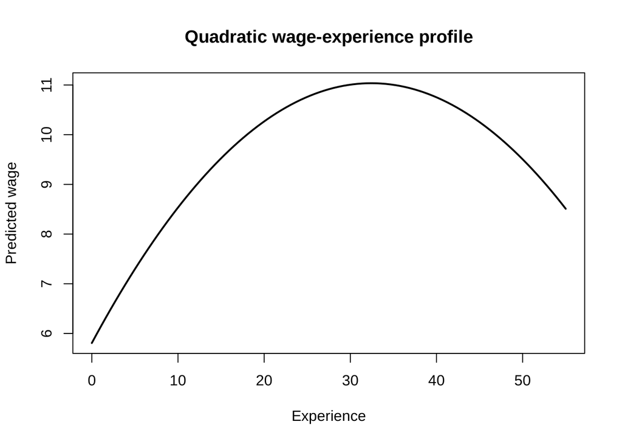

```r
# R code for Question 5(b)

# plot the function with constant education

b0 <- coef(model_quad)["(Intercept)"]
b1 <- coef(model_quad)["education"]
b2 <- coef(model_quad)["experience"]
b3 <- coef(model_quad)["experience_sq"]

mean_edu <- mean(CPS1985$education)

curve( b0 + b1 * mean_edu + b2 * x + b3 * x^2, from = min(CPS1985$experience), to = max(CPS1985$experience),
  xlab = "Experience",
  ylab = "Predicted wage",
  main = "Quadratic wage-experience profile",
  lwd = 2
)
```

```r
# experience at which the fitted wage (at mean education) becomes zero
c0 <- b0 + b1 * mean_edu
(-b2 - sqrt(b2^2 - 4 * b3 * c0)) / (2 * b3)
```

```
## experience
##   79.58166
```

## (c) (2 pt)

Holding experience constant, one additional year of education is associated with approximately $100 \times 0.0894 = 8.94\%$ higher hourly wages. This is the approximation that holds for small changes; the exact effect is $100 \times (e^{0.0894} - 1) = 9.35\%$.

In the level-wage models, one additional year of education is associated with about $0.59 to $0.94 higher hourly wages: 0.73 in Q1, 0.93 to 0.94 in Q3, 0.89 in the Q4 base model, 0.59 in the Q4 alternative model and 0.86 in the quadratic model of Q5(a). The log specification measures relative (percentage) changes in wages, while the level models measure absolute changes in dollars per hour. At the mean wage of $9.25, a 9% increase is roughly $0.83 to $0.86, so the two interpretations are of a similar size.

The $R^2$ of the level quadratic model is 0.212 and the $R^2$ of the log-wage model is 0.203. These cannot be compared directly. The $R^2$ of the log model measures the share of the variation in log(wage) that is explained, whereas the $R^2$ of the level model measures the share of the variation in wage itself. The two dependent variables have a different total variation, so a larger $R^2$ does not mean that one specification is better than the other.

```r
# R code for Question 5(c)

model_log <- lm(
  log(wage) ~ education + experience + experience_sq,
  data = CPS1985
)

summary(model_log)
```

```
##
## Call:
## lm(formula = log(wage) ~ education + experience + experience_sq,
##     data = CPS1985)
##
## Residuals:
##      Min       1Q   Median       3Q      Max
## -2.11687 -0.29294  0.01533  0.32682  1.32095
##
## Coefficients:
##                 Estimate Std. Error t value Pr(>|t|)
## (Intercept)    0.5158323  0.2449681   2.106 0.036640 *
## education      0.0893835  0.0162721   5.493 1.36e-07 ***
## experience     0.0348149  0.0100602   3.461 0.000675 ***
## experience_sq -0.0005332  0.0002263  -2.356 0.019548 *
## ---
## Signif. codes:  0 '***' 0.001 '**' 0.01 '*' 0.05 '.' 0.1 ' ' 1
##
## Residual standard error: 0.483 on 177 degrees of freedom
## Multiple R-squared:  0.2033, Adjusted R-squared:  0.1898
## F-statistic: 15.06 on 3 and 177 DF,  p-value: 9.005e-09
```

```r
coeftest(model_log, vcov = vcovHC(model_log, type = "HC1"))
```

```
##
## t test of coefficients:
##
##                  Estimate  Std. Error t value  Pr(>|t|)
## (Intercept)    0.51583226  0.23036251  2.2392  0.026387 *
## education      0.08938350  0.01556498  5.7426 3.986e-08 ***
## experience     0.03481489  0.01091052  3.1909  0.001678 **
## experience_sq -0.00053319  0.00025890 -2.0594  0.040917 *
## ---
## Signif. codes:  0 '***' 0.001 '**' 0.01 '*' 0.05 '.' 0.1 ' ' 1
```

```r
# approximate and exact percentage effect of one extra year of education
b_educ_log <- coef(model_log)["education"]
c(approximate = 100 * b_educ_log, exact = 100 * (exp(b_educ_log) - 1))
```

```
## approximate.education       exact.education
##              8.938350              9.349993
```

```r
# R-squared of the level and the log model
c(level_quadratic = summary(model_quad)$r.squared, log = summary(model_log)$r.squared)
```

```
## level_quadratic             log
##       0.2118809       0.2033241
```

## (d) (2 pt)

We estimate

$$\log(wage_i) = \beta_0 + \beta_1\,
education_i + \beta_2\, female_i + \beta_3\, (education_i \times
female_i) + \beta_4\, experience_i + \beta_5\, experience_i^2 + u_i
,$$

where $female_i = 1$ for women. R uses female = no (men) as the reference category, so $\beta_2$ is the difference in intercept and $\beta_3$ the difference in the education slope between women and men. The fitted regression functions are

For female = no:

$$\widehat{\log(wage)}_i = 0.8903 +
0.0693\, education_i + 0.0381\, experience_i - 0.000552\,
experience_i^2$$

For female = yes:

$$\widehat{\log(wage)}_i = (0.8903 -
0.9533) + (0.0693 + 0.0462)\, education_i + 0.0381\, experience_i -
0.000552\, experience_i^2$$

$$\widehat{\log(wage)}_i = -0.0631 +
0.1155\, education_i + 0.0381\, experience_i - 0.000552\,
experience_i^2$$

The estimated return to education is about 6.9% per year for men and about 11.5% per year for women (using the approximation $100 \times \hat\beta$; the exact effects are 7.2% and 12.2%).

We test the joint null hypothesis that both the intercept and the education slope are the same for the two groups:

$$H_0: \beta_2 = 0 \text{ and } \beta_3 =
0 \qquad \text{against} \qquad H_1: \beta_2 \neq 0 \text{ or } \beta_3
\neq 0 \text{ (or both)}.$$

The HC1 heteroskedasticity-robust joint test gives $\chi^2 = 29.12$ with a p-value of $4.75 \times 10^{-7}$. Since the p-value is below 0.05, we reject the null hypothesis: the two fitted regression lines are statistically distinguishable at the 5% level.

The joint test only tells us that the two lines differ in the intercept, in the slope, or in both. It does not show that the return to education differs between men and women. With HC1 standard errors, the intercept difference $\hat\beta_2$ is individually significant ($p = 0.008$), but the interaction $\hat\beta_3$ is not significant at the 5% level ($p = 0.082$). So the evidence for a different slope on its own is weak.

Economically, the difference can be meaningful. The estimated return to education is 4.6 percentage points higher for women, which is large, but it is estimated imprecisely. The gender gap in wages depends on education: at 12 years of education women earn about 33% less than men with the same experience, at 16 years about 19% less, and at 18 years about 12% less. The intercept difference of −0.95 itself refers to zero years of education, which is outside the data (the lowest education among women is 6 years), so it should not be interpreted on its own.

```r
# R code for Question 5(d)

model_interact <- lm(log(wage) ~ education * female + experience + experience_sq, data = CPS1985)

summary(model_interact)
```

```
##
## Call:
## lm(formula = log(wage) ~ education * female + experience + experience_sq,
##     data = CPS1985)
##
## Residuals:
##      Min       1Q   Median       3Q      Max
## -2.31847 -0.25476  0.01426  0.30994  1.21461
##
## Coefficients:
##                       Estimate Std. Error t value Pr(>|t|)
## (Intercept)          0.8902563  0.2841511   3.133 0.002029 **
## education            0.0693185  0.0198116   3.499 0.000592 ***
## femaleyes           -0.9533204  0.3803852  -2.506 0.013116 *
## experience           0.0380962  0.0094563   4.029 8.35e-05 ***
## experience_sq       -0.0005519  0.0002126  -2.597 0.010213 *
## education:femaleyes  0.0461637  0.0280034   1.649 0.101044
## ---
## Signif. codes:  0 '***' 0.001 '**' 0.01 '*' 0.05 '.' 0.1 ' ' 1
##
## Residual standard error: 0.4523 on 175 degrees of freedom
## Multiple R-squared:  0.3092, Adjusted R-squared:  0.2894
## F-statistic: 15.66 on 5 and 175 DF,  p-value: 9.909e-13
```

```r
# test

# individual tests with HC1 robust standard errors
coeftest(model_interact, vcov = vcovHC(model_interact, type = "HC1"))
```

```
##
## t test of coefficients:
##
##                        Estimate  Std. Error t value  Pr(>|t|)
## (Intercept)          0.89025634  0.27591116  3.2266  0.001495 **
## education            0.06931850  0.02077167  3.3372  0.001034 **
## femaleyes           -0.95332037  0.35674922 -2.6722  0.008247 **
## experience           0.03809616  0.00919879  4.1414 5.361e-05 ***
## experience_sq       -0.00055194  0.00020631 -2.6753  0.008176 **
## education:femaleyes  0.04616366  0.02642865  1.7467  0.082439 .
## ---
## Signif. codes:  0 '***' 0.001 '**' 0.01 '*' 0.05 '.' 0.1 ' ' 1
```

```r
linearHypothesis(model_interact,c("femaleyes = 0","education:femaleyes = 0"),vcov. = vcovHC(model_interact, type ="HC1"),test="Chisq")
```

```
## Linear hypothesis test
##
## Hypothesis:
## femaleyes = 0
## education:femaleyes = 0
##
## Model 1: restricted model
## Model 2: log(wage) ~ education * female + experience + experience_sq
##
## Note: Coefficient covariance matrix supplied.
##
##   Res.Df Df  Chisq Pr(>Chisq)
## 1    177
## 2    175  2 29.119  4.752e-07 ***
## ---
## Signif. codes:  0 '***' 0.001 '**' 0.01 '*' 0.05 '.' 0.1 ' ' 1
```

```r
# estimated return to education per group (approximate and exact, in %)
ci <- coef(model_interact)
returns <- c(men = unname(ci["education"]),
             women = unname(ci["education"] + ci["education:femaleyes"]))
round(rbind(approximate = 100 * returns, exact = 100 * (exp(returns) - 1)), 1)
```

```
##             men women
## approximate 6.9  11.5
## exact       7.2  12.2
```

```r
# gender wage gap (in %) at 12, 16 and 18 years of education
gap_log <- ci["femaleyes"] + ci["education:femaleyes"] * c(12, 16, 18)
round(100 * (exp(gap_log) - 1), 1)
```

```
## [1] -32.9 -19.3 -11.5
```

```r
range(CPS1985$education[CPS1985$female == "yes"])
```

```
## [1]  6 18
```